# STA 9750 Mini-Project #03: Who Goes There?

- Show All Code
- Hide All Code
- View Source

US Internal Migration and Implications for Congressional Reapportionment in Texas

Author

Raúl J. Solá Navarro

Published

April 25, 2026

# Introduction

Between 2020 and 2024, Texas added more people than any other state in the nation. The Sun Belt surge that has reshaped American politics over the past two decades has made Texas the center of the country’s demographic transformation. As the “Lone Star” gains congressional clout, its northern counterparts watch seats slip away. But what does the data actually say? Where are Texans coming from, where are they going, and can a governor with a targeted advertising budget shift the numbers ahead of the 2030 census?

This report uses American Community Survey (ACS) migration state-to-state and metro-to-metro flow data to quantify those patterns, build population forecasts through 2030, and estimate Texas’s likely congressional apportionment for the 2032 elections. We close with a data-driven advertising strategy designed to maximize the state’s political footprint.

> **Reproducibility note:** All external files are cached in `data/mp03/`. If you are running this document for the first time, the files will be downloaded automatically. Subsequent renders use the cached copies and require no internet access.

# State Population Data

```r
# B01003_001 = Total Population
# Note: 2020 ACS-1 was never released due to COVID-19 low response rates.

pop_raw <- map(
  c(2015:2019, 2021:2024),
  \(yr) get_acs(
    geography   = "state",
    variables   = c(total_population = "B01003_001"),
    year        = yr,
    survey      = "acs1",
    geometry    = TRUE,
    cache_table = TRUE
  ) |>
    mutate(year = yr)
) |>
  list_rbind()

state_pop <- pop_raw |>
  tigris::shift_geometry() |>
  filter(!NAME %in% c("District of Columbia", "Puerto Rico")) |>
  transmute(
    geoid            = GEOID,
    state_name       = NAME,
    state_abbr       = state.abb[match(NAME, state.name)],
    year             = year,
    total_population = estimate,
    pop_moe          = moe,
    geometry         = geometry
  )
```

```r
state_pop_2024 <- state_pop |>
  filter(year == 2024) |>
  arrange(desc(total_population))

bind_rows(
  slice_head(state_pop_2024, n = 10),
  slice_tail(state_pop_2024, n = 10)
) |>
  st_drop_geometry() |>
  mutate(rank = c(1:10, 41:50)) |>
  select(rank, state_name, state_abbr, total_population) |>
  gt(rowname_col = "rank") |>
  tab_header(
    title    = md("**State Populations, 2024 ACS-1 Estimates**"),
    subtitle = "Largest and smallest states by total population"
  ) |>
  cols_label(
    state_name       = "State",
    state_abbr       = "",
    total_population = "Population"
  ) |>
  fmt_integer(total_population) |>
  tab_row_group(label = "10 Smallest States", rows = 11:20) |>
  tab_row_group(label = "10 Largest States",  rows = 1:10)  |>
  tab_style(
    style = list(
      cell_fill(color = "#002868"),
      cell_text(color = "white", weight = "bold")
    ),
    locations = cells_row_groups()
  ) |>
  tab_style(
    style     = cell_fill(color = "#EEF2FF"),
    locations = cells_body(rows = state_abbr == "TX")
  ) |>
  tab_footnote(
    footnote  = "Texas highlighted in blue.",
    locations = cells_column_labels(state_name)
  ) |>
  tab_source_note(
    "Source: US Census Bureau, ACS 1-Year Estimates (2024), Table B01003."
  )
```

**State Populations, 2024 ACS-1 Estimates**

Largest and smallest states by total population

|  | State<sup>1</sup> |  | Population |
| --- | --- | --- | --- |
| 10 Largest States |  |  |  |
| 1 | California | CA | 39,431,263 |
| 2 | Texas | TX | 31,290,831 |
| 3 | Florida | FL | 23,372,215 |
| 4 | New York | NY | 19,867,248 |
| 5 | Pennsylvania | PA | 13,078,751 |
| 6 | Illinois | IL | 12,710,158 |
| 7 | Ohio | OH | 11,883,304 |
| 8 | Georgia | GA | 11,180,878 |
| 9 | North Carolina | NC | 11,046,024 |
| 10 | Michigan | MI | 10,140,459 |
| 10 Smallest States |  |  |  |
| 41 | New Hampshire | NH | 1,409,032 |
| 42 | Maine | ME | 1,405,012 |
| 43 | Montana | MT | 1,137,233 |
| 44 | Rhode Island | RI | 1,112,308 |
| 45 | Delaware | DE | 1,051,917 |
| 46 | South Dakota | SD | 924,669 |
| 47 | North Dakota | ND | 796,568 |
| 48 | Alaska | AK | 740,133 |
| 49 | Vermont | VT | 648,493 |
| 50 | Wyoming | WY | 587,618 |

<sup>1</sup> Texas highlighted in blue.  
Source: US Census Bureau, ACS 1-Year Estimates (2024), Table B01003.

The chart below tracks cumulative population growth since 2015 for Texas and four peer states, indexed to 100 at the start of the period. The 2020 gap reflects the suspension of ACS-1 data collection due to COVID-19 since no ACS-1 was released for that year. Texas and Florida’s trajectories clearly separate them from the pack around 2021.

[figure not shown]

```r
focus_states <- c("Texas", "California", "Florida", "New York", "Arizona")

pop_indexed <- state_pop |>
  st_drop_geometry() |>
  filter(state_name %in% focus_states) |>
  group_by(state_name) |>
  mutate(
    pop_2015 = total_population[year == 2015],
    index    = 100 * total_population / pop_2015
  ) |>
  ungroup()

us_total <- state_pop |>
  st_drop_geometry() |>
  group_by(year) |>
  summarise(total_population = sum(total_population), .groups = "drop") |>
  mutate(
    state_name = "US Total",
    pop_2015   = total_population[year == 2015],
    index      = 100 * total_population / pop_2015
  )

state_colors <- c(
  "Texas"      = "#002868",
  "Florida"    = "#BF0A30",
  "Arizona"    = "#D4A853",
  "California" = "#2E8B8B",
  "New York"   = "#6B6B6B",
  "US Total"   = "black"
)

state_lty <- c(
  "Texas"      = "solid",
  "Florida"    = "solid",
  "Arizona"    = "solid",
  "California" = "solid",
  "New York"   = "solid",
  "US Total"   = "dashed"
)

bind_rows(pop_indexed, us_total) |>
  ggplot(aes(x = year, y = index,
             colour = state_name, linetype = state_name)) +
  geom_line(linewidth = 1.1) +
  geom_point(size = 2) +
  geom_text(
    data = \(d) d |> filter(year == 2024),
    aes(label = glue("{state_name}\n{round(index, 1)}")),
    hjust = -0.08, size = 3, show.legend = FALSE
  ) +
  scale_colour_manual(values = state_colors) +
  scale_linetype_manual(values = state_lty) +
  scale_x_continuous(
    breaks = 2015:2024,
    limits = c(2015, 2026.5)
  ) +
  scale_y_continuous(
    labels = \(x) paste0(x - 100, "%"),
    breaks = seq(95, 125, 5)
  ) +
  labs(
    title    = "Population Growth Since 2015 (Indexed to 100)",
    subtitle = "Texas leads all major states and the national average",
    x        = NULL,
    y        = "Cumulative Growth Since 2015",
    colour   = NULL,
    linetype = NULL,
    caption  = "Source: ACS 1-Year Estimates, Tables B01003 (2015-2024)."
  ) +
  theme_tx() +
  theme(legend.position = "none")
```

# State-to-State Migration Flows

To understand where Texans are coming from, and where they’re going, we turn to the Census Bureau’s state-to-state migration flow files, derived from ACS-1 respondents who reported living in a different state one year prior. We parse the 2023 and 2024 flow files separately (they have different formats) and combine them into a single tidy table.

The table below highlights a striking pattern among the four largest states: California is simultaneously Texas’s largest source of in-migrants (77,161 people) and the top destination for Texans leaving the state (45,447 people). This two-way flow defines the largest migration corridor in the country.

```r
migration_flows |>
  filter(
    state_current %in% c("Texas", "California", "New York", "Florida"),
    state_1y      %in% c("Texas", "California", "New York", "Florida"),
    year_current  == 2024
  ) |>
  arrange(state_current, state_1y) |>
  mutate(
    label = if_else(
      state_current == state_1y,
      glue("Stayed in {state_current}"),
      glue("{state_1y} → {state_current}")
    )
  ) |>
  select(label, population, year_current, year_1y) |>
  gt() |>
  tab_header(
    title    = md("**State-to-State Migration Flows, 2024**"),
    subtitle = "Selected flows among four largest states"
  ) |>
  cols_label(
    label        = "Flow",
    population   = "People",
    year_current = "Survey Year",
    year_1y      = "Prior Year"
  ) |>
  fmt_integer(population) |>
  tab_style(
    style     = cell_fill(color = "#EEF2FF"),
    locations = cells_body(rows = grepl("Texas", label))
  ) |>
  tab_style(
    style = list(
      cell_fill(color = "#002868"),
      cell_text(color = "white", weight = "bold")
    ),
    locations = cells_body(
      rows    = grepl("Stayed", label),
      columns = label
    )
  ) |>
  tab_source_note(
    "Source: US Census Bureau, ACS 1-Year State-to-State Migration Flow Tables."
  )
```

**State-to-State Migration Flows, 2024**

Selected flows among four largest states

| Flow | People | Survey Year | Prior Year |
| --- | --- | --- | --- |
| Stayed in California | 38,325,648 | 2024 | 2023 |
| Florida → California | 15,988 | 2024 | 2023 |
| New York → California | 24,927 | 2024 | 2023 |
| Texas → California | 45,447 | 2024 | 2023 |
| California → Florida | 36,194 | 2024 | 2023 |
| Stayed in Florida | 22,289,936 | 2024 | 2023 |
| New York → Florida | 50,661 | 2024 | 2023 |
| Texas → Florida | 45,259 | 2024 | 2023 |
| California → New York | 31,367 | 2024 | 2023 |
| Florida → New York | 28,080 | 2024 | 2023 |
| Stayed in New York | 19,210,972 | 2024 | 2023 |
| Texas → New York | 16,324 | 2024 | 2023 |
| California → Texas | 77,161 | 2024 | 2023 |
| Florida → Texas | 52,219 | 2024 | 2023 |
| New York → Texas | 28,233 | 2024 | 2023 |
| Stayed in Texas | 30,069,004 | 2024 | 2023 |

Source: US Census Bureau, ACS 1-Year State-to-State Migration Flow Tables.

# Metro-Area Migration Flows

State-level data tells us *where* people are moving in aggregate, but metro-area flows reveal the specific urban corridors driving Texas’s growth. The Houston, Dallas, and Austin metros are among the fastest-growing in the country, but which cities are feeding them? We use the Census Bureau’s ACS-5 metro-to-metro migration API to find out.

The Los Angeles metro sends more people to Texas than any other single metro area with over 27,000 per year during the 2016-2020 period. New York and Chicago follow, confirming that Texas’s growth is largely powered by residents fleeing the high costs and congestion of the country’s three largest legacy metros.

```r
metro_flows |>
  filter(
    metro1_state == "TX",
    !is.na(metro2_state),
    metro2_state != "TX"
  ) |>
  group_by(metro2_name) |>
  summarise(
    total_moved_in = sum(moved_in, na.rm = TRUE),
    .groups = "drop"
  ) |>
  slice_max(total_moved_in, n = 10) |>
  mutate(rank = row_number()) |>
  select(rank, metro2_name, total_moved_in) |>
  gt(rowname_col = "rank") |>
  tab_header(
    title    = md("**Top 10 Metro Sources of In-Migration to Texas**"),
    subtitle = "Non-Texas metros sending the most residents to Texas, ACS 5-Year 2016-2020"
  ) |>
  cols_label(
    metro2_name    = "Origin Metro Area",
    total_moved_in = "People Moved In"
  ) |>
  fmt_integer(total_moved_in) |>
  data_color(
    columns = total_moved_in,
    palette = c("#EEF2FF", "#002868")
  ) |>
  tab_source_note(
    "Source: US Census Bureau, ACS 5-Year Migration Flows API (2016-2020)."
  )
```

**Top 10 Metro Sources of In-Migration to Texas**

Non-Texas metros sending the most residents to Texas, ACS 5-Year 2016-2020

|  | Origin Metro Area | People Moved In |
| --- | --- | --- |
| 1 | Los Angeles-Long Beach-Anaheim, CA Metro Area | 27,445 |
| 2 | New York-Newark-Jersey City, NY-NJ-PA Metro Area | 19,853 |
| 3 | Chicago-Naperville-Elgin, IL-IN-WI Metro Area | 16,253 |
| 4 | Washington-Arlington-Alexandria, DC-VA-MD-WV Metro Area | 14,916 |
| 5 | Phoenix-Mesa-Chandler, AZ Metro Area | 12,695 |
| 6 | San Francisco-Oakland-Berkeley, CA Metro Area | 11,203 |
| 7 | Miami-Fort Lauderdale-Pompano Beach, FL Metro Area | 10,300 |
| 8 | San Diego-Chula Vista-Carlsbad, CA Metro Area | 9,509 |
| 9 | Denver-Aurora-Lakewood, CO Metro Area | 9,222 |
| 10 | Atlanta-Sandy Springs-Alpharetta, GA Metro Area | 9,159 |

Source: US Census Bureau, ACS 5-Year Migration Flows API (2016-2020).

# Exploratory Data Analysis

The following analyses address nine key questions about US internal migration patterns, with particular attention to Texas and the Houston metro area.

## Q1: Highest State Population Growth Rates

Which states have grown the fastest over the past decade? We measure growth as the percentage change in total population from 2015 to 2024. Idaho and Utah lead on a percentage basis, but Texas leads all states in absolute population added with nearly 3.8 million people over the period.

```r
growth_rates <- state_pop |>
  st_drop_geometry() |>
  filter(year %in% c(2015, 2024)) |>
  select(state_name, state_abbr, year, total_population) |>
  pivot_wider(names_from = year, values_from = total_population,
              names_prefix = "pop_") |>
  mutate(
    growth_pct = 100 * (pop_2024 - pop_2015) / pop_2015,
    pop_added  = pop_2024 - pop_2015
  ) |>
  arrange(desc(growth_pct))

growth_rates |>
  slice(c(1:10, 41:50)) |>
  mutate(rank = c(1:10, 41:50)) |>
  select(rank, state_name, state_abbr, pop_2015, pop_2024,
         growth_pct, pop_added) |>
  gt(rowname_col = "rank") |>
  tab_header(
    title    = md("**State Population Growth Rates, 2015-2024**"),
    subtitle = "Fastest and slowest growing states by percentage change"
  ) |>
  cols_label(
    state_name  = "State",
    state_abbr  = "",
    pop_2015    = "2015 Population",
    pop_2024    = "2024 Population",
    growth_pct  = "Growth Rate",
    pop_added   = "People Added"
  ) |>
  fmt_integer(c(pop_2015, pop_2024, pop_added)) |>
  fmt_number(growth_pct, decimals = 1, suffix = "%") |>
  tab_row_group(label = "10 Slowest Growing States", rows = 11:20) |>
  tab_row_group(label = "10 Fastest Growing States", rows = 1:10) |>
  tab_style(
    style = list(
      cell_fill(color = "#002868"),
      cell_text(color = "white", weight = "bold")
    ),
    locations = cells_row_groups()
  ) |>
  tab_style(
    style     = cell_fill(color = "#EEF2FF"),
    locations = cells_body(rows = state_abbr == "TX")
  ) |>
  data_color(
    columns = growth_pct,
    palette = c("#BF0A30", "#FFFFFF", "#002868")
  ) |>
  tab_source_note(
    "Source: ACS 1-Year Estimates, Table B01003 (2015, 2024)."
  )
```

**State Population Growth Rates, 2015-2024**

Fastest and slowest growing states by percentage change

|  | State |  | 2015 Population | 2024 Population | Growth Rate | People Added |
| --- | --- | --- | --- | --- | --- | --- |
| 10 Fastest Growing States |  |  |  |  |  |  |
| 1 | Idaho | ID | 1,654,930 | 2,001,619 | 20.9 | 346,689 |
| 2 | Utah | UT | 2,995,919 | 3,503,613 | 16.9 | 507,694 |
| 3 | Florida | FL | 20,271,272 | 23,372,215 | 15.3 | 3,100,943 |
| 4 | Texas | TX | 27,469,114 | 31,290,831 | 13.9 | 3,821,717 |
| 5 | Nevada | NV | 2,890,845 | 3,267,467 | 13.0 | 376,622 |
| 6 | South Carolina | SC | 4,896,146 | 5,478,831 | 11.9 | 582,685 |
| 7 | Delaware | DE | 945,934 | 1,051,917 | 11.2 | 105,983 |
| 8 | Arizona | AZ | 6,828,065 | 7,582,384 | 11.0 | 754,319 |
| 9 | Washington | WA | 7,170,351 | 7,958,180 | 11.0 | 787,829 |
| 10 | Montana | MT | 1,032,949 | 1,137,233 | 10.1 | 104,284 |
| 10 Slowest Growing States |  |  |  |  |  |  |
| 41 | Kansas | KS | 2,911,641 | 2,970,606 | 2.0 | 58,965 |
| 42 | Hawaii | HI | 1,431,603 | 1,446,146 | 1.0 | 14,543 |
| 43 | California | CA | 39,144,818 | 39,431,263 | 0.7 | 286,445 |
| 44 | New York | NY | 19,795,791 | 19,867,248 | 0.4 | 71,457 |
| 45 | Wyoming | WY | 586,107 | 587,618 | 0.3 | 1,511 |
| 46 | Alaska | AK | 738,432 | 740,133 | 0.2 | 1,701 |
| 47 | Illinois | IL | 12,859,995 | 12,710,158 | −1.2 | −149,837 |
| 48 | Louisiana | LA | 4,670,724 | 4,597,740 | −1.6 | −72,984 |
| 49 | Mississippi | MS | 2,992,333 | 2,943,045 | −1.6 | −49,288 |
| 50 | West Virginia | WV | 1,844,128 | 1,769,979 | −4.0 | −74,149 |

Source: ACS 1-Year Estimates, Table B01003 (2015, 2024).

## Q2: Migration To and From New York State

```r
ny_in <- migration_flows |>
  filter(state_current == "New York",
         state_1y != "New York",
         year_current == 2024) |>
  arrange(desc(population)) |>
  slice_head(n = 10) |>
  mutate(direction = "Into New York")

ny_out <- migration_flows |>
  filter(state_1y == "New York",
         state_current != "New York",
         year_current == 2024) |>
  arrange(desc(population)) |>
  slice_head(n = 10) |>
  mutate(direction = "Out of New York")

bind_rows(
  ny_in  |> select(direction, state = state_1y,      population),
  ny_out |> select(direction, state = state_current, population)
) |>
  group_by(direction) |>
  mutate(rank = row_number()) |>
  ungroup() |>
  pivot_wider(names_from  = direction,
              values_from = c(state, population),
              names_sep   = "_") |>
  select(rank,
         `state_Into New York`, `population_Into New York`,
         `state_Out of New York`, `population_Out of New York`) |>
  gt(rowname_col = "rank") |>
  tab_header(
    title    = md("**New York State Migration Flows, 2024**"),
    subtitle = "Top 10 origin states for in-migrants and destination states for out-migrants"
  ) |>
  cols_label(
    `state_Into New York`        = "Origin State",
    `population_Into New York`   = "People",
    `state_Out of New York`      = "Destination State",
    `population_Out of New York` = "People"
  ) |>
  fmt_integer(c(`population_Into New York`, `population_Out of New York`)) |>
  tab_spanner(label   = "Moving INTO New York",
              columns = c(`state_Into New York`, `population_Into New York`)) |>
  tab_spanner(label   = "Moving OUT of New York",
              columns = c(`state_Out of New York`, `population_Out of New York`)) |>
  tab_style(
    style = list(
      cell_fill(color = "#002868"),
      cell_text(color = "white", weight = "bold")
    ),
    locations = cells_column_spanners()
  ) |>
  tab_source_note(
    "Source: ACS 1-Year State-to-State Migration Flow Tables (2024)."
  )
```

**New York State Migration Flows, 2024**

Top 10 origin states for in-migrants and destination states for out-migrants

|  | Moving INTO New York Origin State | Moving INTO New York People | Moving OUT of New York Destination State | Moving OUT of New York People |
| --- | --- | --- | --- | --- |
| 1 | New Jersey | 36,002 | New Jersey | 56,799 |
| 2 | California | 31,367 | Florida | 50,661 |
| 3 | Florida | 28,080 | Pennsylvania | 29,274 |
| 4 | Pennsylvania | 23,152 | Texas | 28,233 |
| 5 | Massachusetts | 17,862 | Connecticut | 25,095 |
| 6 | Texas | 16,324 | California | 24,927 |
| 7 | Connecticut | 15,160 | Massachusetts | 18,697 |
| 8 | Virginia | 10,310 | South Carolina | 18,324 |
| 9 | North Carolina | 10,076 | North Carolina | 17,978 |
| 10 | Maryland | 8,400 | Virginia | 16,364 |

Source: ACS 1-Year State-to-State Migration Flow Tables (2024).

## Q3: Migration To and From New York City Metro

At the metro level, NYC’s largest domestic migration partner is a relatively short-distance neighbor: Philadelphia. More consequential for Texas is the strong flow from NYC to Miami and Los Angeles, as the data show NYC residents dispersing to desirable Sun Belt cities rather than directly to Texas. Nonetheless, New York City was the 4th-largest source of in-migrants to the Houston metro area specifically.

```r
nyc_pattern <- "New York-Newark-Jersey City"

# Top sources INTO NYC - US metros only, excluding non-metro categories
nyc_in <- metro_flows |>
  filter(
    str_detect(metro1_name, nyc_pattern),
    !str_detect(metro2_name, nyc_pattern),
    str_detect(metro2_name, "Metro Area"),
    !str_detect(metro2_name, "Outside Metro Area"),
    !is.na(moved_in),
    moved_in > 0
  ) |>
  arrange(desc(moved_in)) |>
  slice_head(n = 10) |>
  select(metro = metro2_name, people = moved_in)

# Top destinations OUT of NYC - US metros only
nyc_out <- metro_flows |>
  filter(
    str_detect(metro1_name, nyc_pattern),
    !str_detect(metro2_name, nyc_pattern),
    str_detect(metro2_name, "Metro Area"),
    !str_detect(metro2_name, "Outside Metro Area"),
    !is.na(moved_out),
    moved_out > 0
  ) |>
  arrange(desc(moved_out)) |>
  slice_head(n = 10) |>
  select(metro = metro2_name, people = moved_out)

bind_cols(
  nyc_in  |> mutate(rank = row_number()) |>
    select(rank, in_metro = metro, in_people = people),
  nyc_out |>
    select(out_metro = metro, out_people = people)
) |>
  mutate(
    in_metro  = str_remove(in_metro,  " Metro Area$"),
    out_metro = str_remove(out_metro, " Metro Area$")
  ) |>
  gt(rowname_col = "rank") |>
  tab_header(
    title    = md("**New York City Metro Migration Flows**"),
    subtitle = "Top 10 origin and destination metros, ACS 5-Year 2016-2020"
  ) |>
  cols_label(
    in_metro   = "Origin Metro",
    in_people  = "People",
    out_metro  = "Destination Metro",
    out_people = "People"
  ) |>
  fmt_integer(c(in_people, out_people)) |>
  tab_spanner(label   = "Moving INTO NYC",
              columns = c(in_metro, in_people)) |>
  tab_spanner(label   = "Moving OUT of NYC",
              columns = c(out_metro, out_people)) |>
  tab_style(
    style = list(
      cell_fill(color = "#002868"),
      cell_text(color = "white", weight = "bold")
    ),
    locations = cells_column_spanners()
  ) |>
  tab_source_note(
    "Source: ACS 5-Year Metro-to-Metro Migration Flows API (2016-2020)."
  )
```

**New York City Metro Migration Flows**

Top 10 origin and destination metros, ACS 5-Year 2016-2020

|  | Moving INTO NYC Origin Metro | Moving INTO NYC People | Moving OUT of NYC Destination Metro | Moving OUT of NYC People |
| --- | --- | --- | --- | --- |
| 1 | Philadelphia-Camden-Wilmington, PA-NJ-DE-MD | 19,600 | Philadelphia-Camden-Wilmington, PA-NJ-DE-MD | 35,254 |
| 2 | Washington-Arlington-Alexandria, DC-VA-MD-WV | 11,162 | Miami-Fort Lauderdale-Pompano Beach, FL | 22,411 |
| 3 | Boston-Cambridge-Newton, MA-NH | 10,019 | Washington-Arlington-Alexandria, DC-VA-MD-WV | 17,558 |
| 4 | Los Angeles-Long Beach-Anaheim, CA | 9,761 | Los Angeles-Long Beach-Anaheim, CA | 17,107 |
| 5 | Poughkeepsie-Newburgh-MiddleTown, NY | 9,492 | Bridgeport-Stamford-Norwalk, CT | 16,709 |
| 6 | Miami-Fort Lauderdale-Pompano Beach, FL | 8,085 | Poughkeepsie-Newburgh-MiddleTown, NY | 15,475 |
| 7 | Bridgeport-Stamford-Norwalk, CT | 7,534 | Boston-Cambridge-Newton, MA-NH | 15,162 |
| 8 | Trenton-Princeton, NJ | 7,208 | Atlanta-Sandy Springs-Alpharetta, GA | 12,928 |
| 9 | San Francisco-Oakland-Berkeley, CA | 6,923 | Trenton-Princeton, NJ | 12,735 |
| 10 | Albany-Schenectady-Troy, NY | 5,512 | Allentown-Bethlehem-Easton, PA-NJ | 12,284 |

Source: ACS 5-Year Metro-to-Metro Migration Flows API (2016-2020).

## Q4: States With Highest In-, Out-, and Net Migration

Texas leads all states in net domestic in-migration with a surplus of nearly 72,000 people in 2024. At the other extreme, California experienced the largest domestic out-migration drain in the country, losing a net 252,000 residents to other states. Florida’s total flows in both directions reflect its role as both a major destination and a pass-through state.

```r
state_migration_totals <- migration_flows |>
  filter(
    state_current != state_1y,
    year_current  == 2024
  ) |>
  group_by(state = state_current) |>
  summarise(total_in = sum(population, na.rm = TRUE), .groups = "drop") |>
  left_join(
    migration_flows |>
      filter(state_current != state_1y, year_current == 2024) |>
      group_by(state = state_1y) |>
      summarise(total_out = sum(population, na.rm = TRUE), .groups = "drop"),
    by = "state"
  ) |>
  mutate(net_migration = total_in - total_out) |>
  arrange(desc(net_migration))

state_migration_totals |>
  slice(c(1:10, 41:50)) |>
  mutate(rank = c(1:10, 41:50)) |>
  left_join(
    state_pop |> st_drop_geometry() |>
      filter(year == 2024) |>
      select(state_name, state_abbr),
    by = c("state" = "state_name")
  ) |>
  select(rank, state, state_abbr, total_in, total_out, net_migration) |>
  gt(rowname_col = "rank") |>
  tab_header(
    title    = md("**State Migration Totals, 2024**"),
    subtitle = "Highest and lowest net migration states"
  ) |>
  cols_label(
    state         = "State",
    state_abbr    = "",
    total_in      = "In-Migration",
    total_out     = "Out-Migration",
    net_migration = "Net Migration"
  ) |>
  fmt_integer(c(total_in, total_out, net_migration)) |>
  tab_row_group(label = "10 Highest Net Out-Migration", rows = 11:20) |>
  tab_row_group(label = "10 Highest Net In-Migration",  rows = 1:10)  |>
  tab_style(
    style = list(
      cell_fill(color = "#002868"),
      cell_text(color = "white", weight = "bold")
    ),
    locations = cells_row_groups()
  ) |>
  tab_style(
    style     = cell_fill(color = "#EEF2FF"),
    locations = cells_body(rows = state == "Texas")
  ) |>
  data_color(
    columns = net_migration,
    palette = c("#BF0A30", "#FFFFFF", "#002868")
  ) |>
  tab_source_note(
    "Source: ACS 1-Year State-to-State Migration Flow Tables (2024)."
  )
```

**State Migration Totals, 2024**

Highest and lowest net migration states

|  | State |  | In-Migration | Out-Migration | Net Migration |
| --- | --- | --- | --- | --- | --- |
| 10 Highest Net In-Migration |  |  |  |  |  |
| 1 | Texas | TX | 553,869 | 482,029 | 71,840 |
| 2 | Florida | FL | 571,998 | 505,072 | 66,926 |
| 3 | North Carolina | NC | 297,704 | 239,780 | 57,924 |
| 4 | Arizona | AZ | 234,723 | 178,678 | 56,045 |
| 5 | South Carolina | SC | 189,282 | 134,348 | 54,934 |
| 6 | Nevada | NV | 129,109 | 88,898 | 40,211 |
| 7 | Georgia | GA | 265,364 | 228,039 | 37,325 |
| 8 | Tennessee | TN | 191,386 | 155,499 | 35,887 |
| 9 | Oklahoma | OK | 106,621 | 72,461 | 34,160 |
| 10 | Alabama | AL | 119,767 | 97,317 | 22,450 |
| 10 Highest Net Out-Migration |  |  |  |  |  |
| 41 | Iowa | IA | 59,199 | 69,417 | −10,218 |
| 42 | Alaska | AK | 29,456 | 39,842 | −10,386 |
| 43 | Louisiana | LA | 70,847 | 82,616 | −11,769 |
| 44 | Pennsylvania | PA | 232,208 | 247,858 | −15,650 |
| 45 | Colorado | CO | 181,683 | 204,323 | −22,640 |
| 46 | Massachusetts | MA | 150,513 | 180,497 | −29,984 |
| 47 | New Jersey | NJ | 149,512 | 211,969 | −62,457 |
| 48 | Illinois | IL | 199,235 | 279,613 | −80,378 |
| 49 | New York | NY | 280,073 | 412,187 | −132,114 |
| 50 | California | CA | 404,745 | 656,646 | −251,901 |

Source: ACS 1-Year State-to-State Migration Flow Tables (2024).

## Q5: Metro Areas With Highest In-, Out-, and Net Migration

At the metro level, Phoenix leads all US metros in net in-migration, followed by Riverside and Dallas-Fort Worth. Notably, two Texas metros, Dallas-Fort Worth and Austin, rank in the top four nationally. The bottom of the table is dominated by coastal legacy metros: New York, Los Angeles, Chicago, and San Francisco all rank among the largest net losers.

```r
metro_totals <- metro_flows |>
  filter(!is.na(metro1_state), !is.na(metro2_state)) |>
  group_by(metro = metro1_name, state = metro1_state) |>
  summarise(
    total_in  = sum(moved_in,  na.rm = TRUE),
    total_out = sum(moved_out, na.rm = TRUE),
    .groups   = "drop"
  ) |>
  mutate(
    net_migration = total_in - total_out,
    metro_short   = str_remove(metro, " Metro Area$")
  ) |>
  arrange(desc(net_migration))

metro_totals |>
  slice(c(1:10, (nrow(metro_totals) - 9):nrow(metro_totals))) |>
  mutate(rank = c(1:10, (nrow(metro_totals) - 9):nrow(metro_totals))) |>
  select(rank, metro_short, state, total_in, total_out, net_migration) |>
  gt(rowname_col = "rank") |>
  tab_header(
    title    = md("**Metro Area Migration Totals**"),
    subtitle = "Highest and lowest net migration metros, ACS 5-Year 2016-2020"
  ) |>
  cols_label(
    metro_short   = "Metro Area",
    state         = "State",
    total_in      = "In-Migration",
    total_out     = "Out-Migration",
    net_migration = "Net Migration"
  ) |>
  fmt_integer(c(total_in, total_out, net_migration)) |>
  tab_row_group(label = "10 Highest Net Out-Migration", rows = 11:20) |>
  tab_row_group(label = "10 Highest Net In-Migration",  rows = 1:10)  |>
  tab_style(
    style = list(
      cell_fill(color = "#002868"),
      cell_text(color = "white", weight = "bold")
    ),
    locations = cells_row_groups()
  ) |>
  data_color(
    columns = net_migration,
    palette = c("#BF0A30", "#FFFFFF", "#002868")
  ) |>
  tab_source_note(
    "Source: ACS 5-Year Metro-to-Metro Migration Flows API (2016-2020)."
  )
```

**Metro Area Migration Totals**

Highest and lowest net migration metros, ACS 5-Year 2016-2020

|  | Metro Area | State | In-Migration | Out-Migration | Net Migration |
| --- | --- | --- | --- | --- | --- |
| 10 Highest Net In-Migration |  |  |  |  |  |
| 1 | Phoenix-Mesa-Chandler, AZ | AZ | 182,053 | 126,179 | 55,874 |
| 2 | Riverside-San Bernardino-Ontario, CA | CA | 178,045 | 137,731 | 40,314 |
| 3 | Dallas-Fort Worth-Arlington, TX | TX | 215,511 | 180,491 | 35,020 |
| 4 | Austin-Round Rock-GeorgeTown, TX | TX | 116,913 | 85,901 | 31,012 |
| 5 | Las Vegas-Henderson-Paradise, NV | NV | 92,544 | 61,696 | 30,848 |
| 6 | Tampa-St. Petersburg-Clearwater, FL | FL | 134,637 | 105,146 | 29,491 |
| 7 | Orlando-Kissimmee-Sanford, FL | FL | 133,976 | 105,395 | 28,581 |
| 8 | Jacksonville, FL | FL | 73,419 | 54,772 | 18,647 |
| 9 | Deltona-Daytona Beach-Ormond Beach, FL | FL | 41,276 | 23,312 | 17,964 |
| 10 | Nashville-Davidson--Murfreesboro--Franklin, TN | TN | 73,461 | 55,589 | 17,872 |
| 10 Highest Net Out-Migration |  |  |  |  |  |
| 383 | Detroit-Warren-Dearborn, MI | MI | 72,716 | 94,314 | −21,598 |
| 384 | Boston-Cambridge-Newton, MA-NH | MA | 134,190 | 160,705 | −26,515 |
| 385 | San Jose-Sunnyvale-Santa Clara, CA | CA | 78,555 | 107,431 | −28,876 |
| 386 | Miami-Fort Lauderdale-Pompano Beach, FL | FL | 135,718 | 176,510 | −40,792 |
| 387 | San Juan-Bayamón-Caguas, PR | PR | 20,943 | 62,430 | −41,487 |
| 388 | Washington-Arlington-Alexandria, DC-VA-MD-WV | DC | 209,588 | 251,422 | −41,834 |
| 389 | San Francisco-Oakland-Berkeley, CA | CA | 162,213 | 204,077 | −41,864 |
| 390 | Chicago-Naperville-Elgin, IL-IN-WI | IL | 156,175 | 245,692 | −89,517 |
| 391 | Los Angeles-Long Beach-Anaheim, CA | CA | 242,529 | 375,810 | −133,281 |
| 392 | New York-Newark-Jersey City, NY-NJ-PA | NY | 235,844 | 490,636 | −254,792 |

Source: ACS 5-Year Metro-to-Metro Migration Flows API (2016-2020).

## Q6: States With Lowest Proportional In-Migration

What are the “sticky” states where residents are least likely to have moved from elsewhere? California leads this ranking, with just 1.05% of its population having arrived from another state in 2024. Texas ranks 9th on this list despite its rapid growth, reflecting the fact that its enormous existing population base dilutes even large absolute in-migration flows.

```r
migration_flows |>
  filter(year_current == 2024) |>
  group_by(state = state_current) |>
  summarise(
    total_pop = sum(population, na.rm = TRUE),
    moved_in  = sum(population[state_current != state_1y], na.rm = TRUE),
    .groups   = "drop"
  ) |>
  mutate(pct_moved_in = 100 * moved_in / total_pop) |>
  arrange(pct_moved_in) |>
  slice(c(1:10, 41:50)) |>
  mutate(rank = c(1:10, 41:50)) |>
  left_join(
    state_pop |> st_drop_geometry() |>
      filter(year == 2024) |>
      select(state_name, state_abbr),
    by = c("state" = "state_name")
  ) |>
  select(rank, state, state_abbr, total_pop, moved_in, pct_moved_in) |>
  gt(rowname_col = "rank") |>
  tab_header(
    title    = md("**State Population Stickiness, 2024**"),
    subtitle = "States ranked by fraction of residents who moved in from another state"
  ) |>
  cols_label(
    state        = "State",
    state_abbr   = "",
    total_pop    = "Total Population",
    moved_in     = "Moved In From Another State",
    pct_moved_in = "% In-Migrants"
  ) |>
  fmt_integer(c(total_pop, moved_in)) |>
  fmt_number(pct_moved_in, decimals = 2, suffix = "%") |>
  tab_row_group(label = "10 Least Sticky (Most In-Migration)", rows = 11:20) |>
  tab_row_group(label = "10 Most Sticky (Least In-Migration)", rows = 1:10)  |>
  tab_style(
    style = list(
      cell_fill(color = "#002868"),
      cell_text(color = "white", weight = "bold")
    ),
    locations = cells_row_groups()
  ) |>
  tab_style(
    style     = cell_fill(color = "#EEF2FF"),
    locations = cells_body(rows = state == "Texas")
  ) |>
  data_color(
    columns = pct_moved_in,
    palette = c("#EEF2FF", "#002868")
  ) |>
  tab_source_note(
    "Source: ACS 1-Year State-to-State Migration Flow Tables (2024)."
  )
```

**State Population Stickiness, 2024**

States ranked by fraction of residents who moved in from another state

|  | State |  | Total Population | Moved In From Another State | % In-Migrants |
| --- | --- | --- | --- | --- | --- |
| 10 Most Sticky (Least In-Migration) |  |  |  |  |  |
| 1 | California | CA | 38,730,393 | 404,745 | 1.05 |
| 2 | Michigan | MI | 9,988,333 | 139,882 | 1.40 |
| 3 | New York | NY | 19,491,045 | 280,073 | 1.44 |
| 4 | Louisiana | LA | 4,520,727 | 70,847 | 1.57 |
| 5 | Illinois | IL | 12,491,116 | 199,235 | 1.60 |
| 6 | New Jersey | NJ | 9,309,234 | 149,512 | 1.61 |
| 7 | Ohio | OH | 11,704,591 | 197,471 | 1.69 |
| 8 | Pennsylvania | PA | 12,886,895 | 232,208 | 1.80 |
| 9 | Texas | TX | 30,622,873 | 553,869 | 1.81 |
| 10 | Minnesota | MN | 5,698,255 | 103,924 | 1.82 |
| 10 Least Sticky (Most In-Migration) |  |  |  |  |  |
| 41 | Rhode Island | RI | 1,090,525 | 34,860 | 3.20 |
| 42 | New Hampshire | NH | 1,389,355 | 45,900 | 3.30 |
| 43 | North Dakota | ND | 781,941 | 27,062 | 3.46 |
| 44 | South Carolina | SC | 5,391,825 | 189,282 | 3.51 |
| 45 | Idaho | ID | 1,970,568 | 72,442 | 3.68 |
| 46 | Vermont | VT | 641,786 | 23,884 | 3.72 |
| 47 | Hawaii | HI | 1,419,055 | 53,093 | 3.74 |
| 48 | Nevada | NV | 3,205,924 | 129,109 | 4.03 |
| 49 | Alaska | AK | 724,947 | 29,456 | 4.06 |
| 50 | Wyoming | WY | 579,872 | 25,060 | 4.32 |

Source: ACS 1-Year State-to-State Migration Flow Tables (2024).

## Q7: States Where Migration Drives the Most Growth

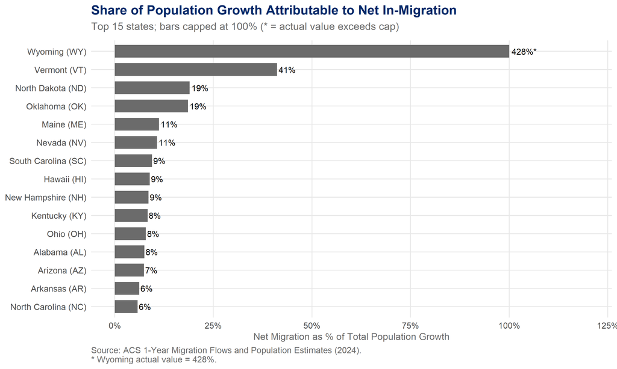

```r
migration_growth_share <- state_migration_totals |>
  left_join(growth_rates, by = c("state" = "state_name")) |>
  filter(!is.na(pop_added), pop_added > 0) |>
  mutate(migration_share = 100 * net_migration / pop_added) |>
  filter(!is.na(migration_share), is.finite(migration_share)) |>
  arrange(desc(migration_share))

plot_data <- migration_growth_share |>
  slice_max(migration_share, n = 15) |>
  mutate(
    state_label      = glue("{state} ({state_abbr})"),
    is_texas         = state == "Texas",
    migration_capped = pmin(migration_share, 100),
    label_text       = if_else(
      migration_share > 100,
      paste0(round(migration_share, 0), "%*"),
      paste0(round(migration_share, 0), "%")
    )
  )

ggplot(plot_data,
       aes(x = reorder(state_label, migration_share),
           y = migration_capped,
           fill = is_texas)) +
  geom_col(width = 0.7) +
  geom_text(
    aes(label = label_text),
    hjust = -0.1, size = 3.5
  ) +
  scale_fill_manual(
    values = c("FALSE" = "#6B6B6B", "TRUE" = "#002868"),
    guide  = "none"
  ) +
  scale_y_continuous(
    limits = c(0, 120),
    labels = \(x) paste0(x, "%")
  ) +
  coord_flip() +
  labs(
    title    = "Share of Population Growth Attributable to Net In-Migration",
    subtitle = "Top 15 states; bars capped at 100% (* = actual value exceeds cap)",
    x        = NULL,
    y        = "Net Migration as % of Total Population Growth",
    caption  = "Source: ACS 1-Year Migration Flows and Population Estimates (2024).\n* Wyoming actual value = 428%."
  ) +
  theme_tx()
```

## Q8: Texas-Specific Migration Patterns

The more telling pattern for Texas’s congressional position involves Oklahoma and Colorado. Unlike California, where the flow runs heavily in both directions, Texans are leaving for Oklahoma and Colorado at high rates without equivalent numbers coming back. This is a net drain worth targeting, and notably, Oklahoma leans politically closer to Texas than Colorado does, making it a particularly promising market for a retention campaign.

```r
tx_in <- migration_flows |>
  filter(
    state_current == "Texas",
    state_1y      != "Texas",
    year_current  == 2024
  ) |>
  arrange(desc(population)) |>
  slice_head(n = 10)

tx_out <- migration_flows |>
  filter(
    state_1y      == "Texas",
    state_current != "Texas",
    year_current  == 2024
  ) |>
  arrange(desc(population)) |>
  slice_head(n = 10)

bind_cols(
  tx_in  |> mutate(rank = row_number()) |>
    select(rank, in_state = state_1y, in_pop = population),
  tx_out |>
    select(out_state = state_current, out_pop = population)
) |>
  gt(rowname_col = "rank") |>
  tab_header(
    title    = md("**Texas Migration Flows, 2024**"),
    subtitle = "Top 10 origin states for in-migrants and destinations for out-migrants"
  ) |>
  cols_label(
    in_state  = "Origin State",
    in_pop    = "People Moving In",
    out_state = "Destination State",
    out_pop   = "People Moving Out"
  ) |>
  fmt_integer(c(in_pop, out_pop)) |>
  tab_spanner(
    label   = "Moving INTO Texas",
    columns = c(in_state, in_pop)
  ) |>
  tab_spanner(
    label   = "Moving OUT of Texas",
    columns = c(out_state, out_pop)
  ) |>
  tab_style(
    style = list(
      cell_fill(color = "#002868"),
      cell_text(color = "white", weight = "bold")
    ),
    locations = cells_column_spanners()
  ) |>
  tab_source_note(
    "Source: ACS 1-Year State-to-State Migration Flow Tables (2024)."
  )
```

**Texas Migration Flows, 2024**

Top 10 origin states for in-migrants and destinations for out-migrants

|  | Moving INTO Texas Origin State | Moving INTO Texas People Moving In | Moving OUT of Texas Destination State | Moving OUT of Texas People Moving Out |
| --- | --- | --- | --- | --- |
| 1 | California | 77,161 | California | 45,447 |
| 2 | Florida | 52,219 | Florida | 45,259 |
| 3 | New York | 28,233 | Oklahoma | 28,074 |
| 4 | Louisiana | 24,170 | Colorado | 27,574 |
| 5 | Illinois | 23,509 | Georgia | 20,968 |
| 6 | Colorado | 22,986 | Louisiana | 19,850 |
| 7 | Georgia | 19,481 | Illinois | 18,189 |
| 8 | Oklahoma | 18,579 | North Carolina | 16,498 |
| 9 | Virginia | 17,996 | New York | 16,324 |
| 10 | Washington | 15,937 | Washington | 16,202 |

Source: ACS 1-Year State-to-State Migration Flow Tables (2024).

## Q9: Houston Metro Migration Patterns

Houston is Texas’s largest metro area. Within Texas, Houston exchanges people heavily with Dallas-Fort Worth, Austin, and San Antonio. This reflects how Texans move between the state’s major cities and economic centers. The connection-strength chart below reveals which metros are most disproportionately tied to Houston relative to their total out-migration.

```r
houston_pattern <- "Houston-The Woodlands-Sugar Land"

# Top sources INTO Houston - US metros only
houston_in <- metro_flows |>
  filter(
    str_detect(metro1_name, houston_pattern),
    !str_detect(metro2_name, houston_pattern),
    str_detect(metro2_name, "Metro Area"),
    !str_detect(metro2_name, "Outside Metro Area"),
    !is.na(moved_in),
    moved_in > 0
  ) |>
  arrange(desc(moved_in)) |>
  slice_head(n = 10)

# Top destinations OUT of Houston - US metros only
houston_out <- metro_flows |>
  filter(
    str_detect(metro1_name, houston_pattern),
    !str_detect(metro2_name, houston_pattern),
    str_detect(metro2_name, "Metro Area"),
    !str_detect(metro2_name, "Outside Metro Area"),
    !is.na(moved_out),
    moved_out > 0
  ) |>
  arrange(desc(moved_out)) |>
  slice_head(n = 10)

bind_cols(
  houston_in  |> mutate(rank = row_number()) |>
    select(rank, in_metro = metro2_name, in_people = moved_in),
  houston_out |>
    select(out_metro = metro2_name, out_people = moved_out)
) |>
  mutate(
    in_metro  = str_remove(in_metro,  " Metro Area$"),
    out_metro = str_remove(out_metro, " Metro Area$")
  ) |>
  gt(rowname_col = "rank") |>
  tab_header(
    title    = md("**Houston Metro Migration Flows**"),
    subtitle = "Top 10 origin and destination metros, ACS 5-Year 2016-2020"
  ) |>
  cols_label(
    in_metro   = "Origin Metro",
    in_people  = "People",
    out_metro  = "Destination Metro",
    out_people = "People"
  ) |>
  fmt_integer(c(in_people, out_people)) |>
  tab_spanner(
    label   = "Moving INTO Houston",
    columns = c(in_metro, in_people)
  ) |>
  tab_spanner(
    label   = "Moving OUT of Houston",
    columns = c(out_metro, out_people)
  ) |>
  tab_style(
    style = list(
      cell_fill(color = "#002868"),
      cell_text(color = "white", weight = "bold")
    ),
    locations = cells_column_spanners()
  ) |>
  tab_source_note(
    "Source: ACS 5-Year Metro-to-Metro Migration Flows API (2016-2020)."
  )
```

**Houston Metro Migration Flows**

Top 10 origin and destination metros, ACS 5-Year 2016-2020

|  | Moving INTO Houston Origin Metro | Moving INTO Houston People | Moving OUT of Houston Destination Metro | Moving OUT of Houston People |
| --- | --- | --- | --- | --- |
| 1 | Dallas-Fort Worth-Arlington, TX | 17,235 | Dallas-Fort Worth-Arlington, TX | 17,218 |
| 2 | Austin-Round Rock-GeorgeTown, TX | 10,056 | Austin-Round Rock-GeorgeTown, TX | 15,222 |
| 3 | San Antonio-New Braunfels, TX | 9,134 | San Antonio-New Braunfels, TX | 8,932 |
| 4 | New York-Newark-Jersey City, NY-NJ-PA | 5,719 | College Station-Bryan, TX | 6,193 |
| 5 | College Station-Bryan, TX | 4,709 | Beaumont-Port Arthur, TX | 4,765 |
| 6 | Beaumont-Port Arthur, TX | 4,407 | Lubbock, TX | 2,955 |
| 7 | Washington-Arlington-Alexandria, DC-VA-MD-WV | 4,166 | Atlanta-Sandy Springs-Alpharetta, GA | 2,842 |
| 8 | Los Angeles-Long Beach-Anaheim, CA | 4,082 | Denver-Aurora-Lakewood, CO | 2,699 |
| 9 | Chicago-Naperville-Elgin, IL-IN-WI | 4,031 | McAllen-Edinburg-Mission, TX | 2,664 |
| 10 | New Orleans-Metairie, LA | 3,789 | Seattle-Tacoma-Bellevue, WA | 2,504 |

Source: ACS 5-Year Metro-to-Metro Migration Flows API (2016-2020).

The chart below identified each metro’s draw to Houston measured as the share of its total out-migration that flows specifically to Houston. Metros near the top of this list are the most fertile advertising targets: their residents are already choosing Houston at an unusually high rate, suggesting strong word-of-mouth networks and existing community ties.

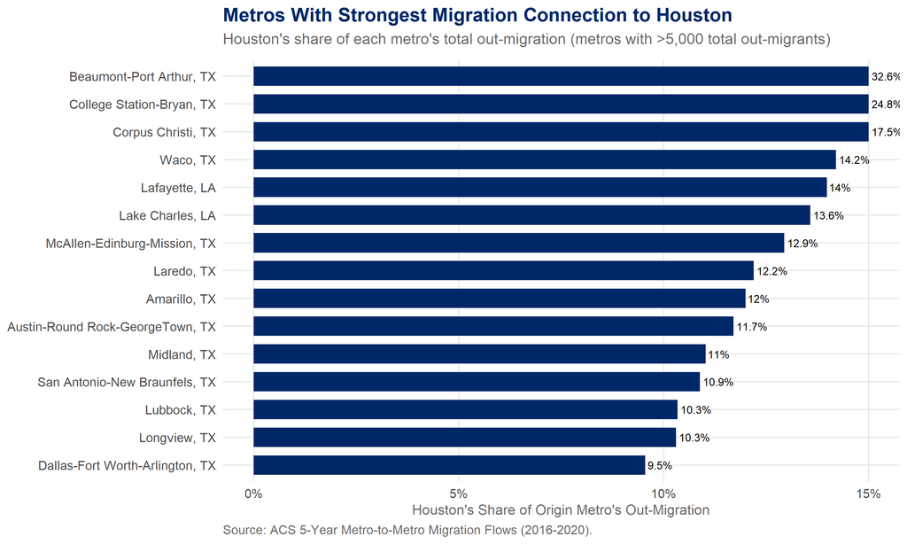

Metros with the strongest migration connection to Houston, measured as Houston’s share of total out-migration from each origin metro. A high share indicates Houston is a uniquely popular destination.

```r
metro_flows |>
  filter(
    str_detect(metro1_name, houston_pattern),
    !str_detect(metro2_name, houston_pattern),
    str_detect(metro2_name, "Metro Area"),
    !str_detect(metro2_name, "Outside Metro Area"),
    !is.na(moved_in),
    moved_in > 0,
    !is.na(metro2_state)
  ) |>
  left_join(
    metro_totals |> select(metro, total_out),
    by = c("metro2_name" = "metro")
  ) |>
  mutate(
    houston_share = 100 * moved_in / total_out,
    metro_short   = str_remove(metro2_name, " Metro Area$")
  ) |>
  filter(!is.na(houston_share), total_out > 5000) |>
  slice_max(houston_share, n = 15) |>
  ggplot(aes(x = reorder(metro_short, houston_share),
             y = houston_share)) +
  geom_col(fill = "#002868", width = 0.7) +
  geom_text(
    aes(label = paste0(round(houston_share, 1), "%")),
    hjust = -0.1, size = 3
  ) +
  scale_y_continuous(
    limits = c(0, 15),
    labels = \(x) paste0(x, "%"),
    oob    = scales::squish
  ) +
  coord_flip() +
  labs(
    title    = "Metros With Strongest Migration Connection to Houston",
    subtitle = "Houston's share of each metro's total out-migration (metros with >5,000 total out-migrants)",
    x        = NULL,
    y        = "Houston's Share of Origin Metro's Out-Migration",
    caption  = "Source: ACS 5-Year Metro-to-Metro Migration Flows (2016-2020)."
  ) +
  theme_tx()
```

# Population Projections to 2030

To estimate Texas’s congressional apportionment after the 2030 census, we first need to forecast each state’s 2030 population. We use the migration model described in the assignment[^1], which assumes population growth follows:

$$P_{i,t+1} = P_{i,t} \cdot (1 + \gamma) + \sum_{j \neq i} \lambda_{ij} \cdot P_{i,t} \cdot P_{j,t}$$

where $\gamma$ is a national natural growth rate and $\lambda_{ij}$ captures the migration flow rate from state $j$ to state $i$. We fit parameters using both the 2023 and 2024 flow files and average the lambda values for stability. Because the 2023 file format does not fully capture stationary population, gamma (the natural growth rate) is estimated from 2024 data only, yielding γ = −0.27% per year. This slightly negative value reflects the fact that the ACS domestic flow tables do not capture international immigration, which has been a substantial driver of US population growth. As a result, our projections should be interpreted as conservative estimates on the low end, particularly for high-immigration states like Texas.

The table below shows projected 2030 populations for the 10 largest and 10 smallest states. Under this conservative model, most states show modest population declines driven by the negative gamma and reminds us that these projections exclude international immigration and should be read as a domestic-migration-only baseline.

```r
pop_2030 <- pop_projections |>
  filter(year == 2030) |>
  arrange(desc(total_population))

pop_2030 |>
  slice(c(1:10, 41:50)) |>
  mutate(rank = c(1:10, 41:50)) |>
  left_join(
    pop_2024 |>
      st_drop_geometry() |>
      select(state_name, pop_2024 = total_population),
    by = "state_name"
  ) |>
  mutate(projected_growth = total_population - pop_2024) |>
  select(rank, state_name, state_abbr,
         pop_2024, total_population, projected_growth) |>
  gt(rowname_col = "rank") |>
  tab_header(
    title    = md("**Projected State Populations, 2030**"),
    subtitle = "Based on averaged 2023-2024 migration parameters"
  ) |>
  cols_label(
    state_name       = "State",
    state_abbr       = "",
    pop_2024         = "2024 Population",
    total_population = "Projected 2030 Population",
    projected_growth = "Projected Growth"
  ) |>
  fmt_integer(c(pop_2024, total_population, projected_growth)) |>
  tab_row_group(label = "10 Smallest Projected States", rows = 11:20) |>
  tab_row_group(label = "10 Largest Projected States",  rows = 1:10)  |>
  tab_style(
    style = list(
      cell_fill(color = "#002868"),
      cell_text(color = "white", weight = "bold")
    ),
    locations = cells_row_groups()
  ) |>
  tab_style(
    style     = cell_fill(color = "#EEF2FF"),
    locations = cells_body(rows = state_abbr == "TX")
  ) |>
  data_color(
    columns = projected_growth,
    palette = c("#BF0A30", "#FFFFFF", "#002868")
  ) |>
  tab_source_note(
    "Source: ACS 1-Year Estimates + author projections using averaged 2023-2024 migration parameters."
  )
```

**Projected State Populations, 2030**

Based on averaged 2023-2024 migration parameters

|  | State |  | 2024 Population | Projected 2030 Population | Projected Growth |
| --- | --- | --- | --- | --- | --- |
| 10 Largest Projected States |  |  |  |  |  |
| 1 | California | CA | 39,431,263 | 38,874,574 | −556,689 |
| 2 | Texas | TX | 31,290,831 | 30,543,128 | −747,703 |
| 3 | Florida | FL | 23,372,215 | 22,750,215 | −622,000 |
| 4 | New York | NY | 19,867,248 | 19,703,296 | −163,952 |
| 5 | Pennsylvania | PA | 13,078,751 | 12,929,329 | −149,422 |
| 6 | Illinois | IL | 12,710,158 | 12,555,657 | −154,501 |
| 7 | Ohio | OH | 11,883,304 | 11,752,521 | −130,783 |
| 8 | Georgia | GA | 11,180,878 | 10,926,885 | −253,993 |
| 9 | North Carolina | NC | 11,046,024 | 10,702,252 | −343,772 |
| 10 | Michigan | MI | 10,140,459 | 10,056,924 | −83,535 |
| 10 Smallest Projected States |  |  |  |  |  |
| 41 | New Hampshire | NH | 1,409,032 | 1,429,413 | 20,381 |
| 42 | Maine | ME | 1,405,012 | 1,371,444 | −33,568 |
| 43 | Montana | MT | 1,137,233 | 1,121,845 | −15,388 |
| 44 | Rhode Island | RI | 1,112,308 | 1,104,582 | −7,726 |
| 45 | Delaware | DE | 1,051,917 | 1,019,574 | −32,343 |
| 46 | South Dakota | SD | 924,669 | 888,092 | −36,577 |
| 47 | North Dakota | ND | 796,568 | 764,302 | −32,266 |
| 48 | Alaska | AK | 740,133 | 714,992 | −25,141 |
| 49 | Vermont | VT | 648,493 | 643,941 | −4,552 |
| 50 | Wyoming | WY | 587,618 | 598,345 | 10,727 |

Source: ACS 1-Year Estimates + author projections using averaged 2023-2024 migration parameters.

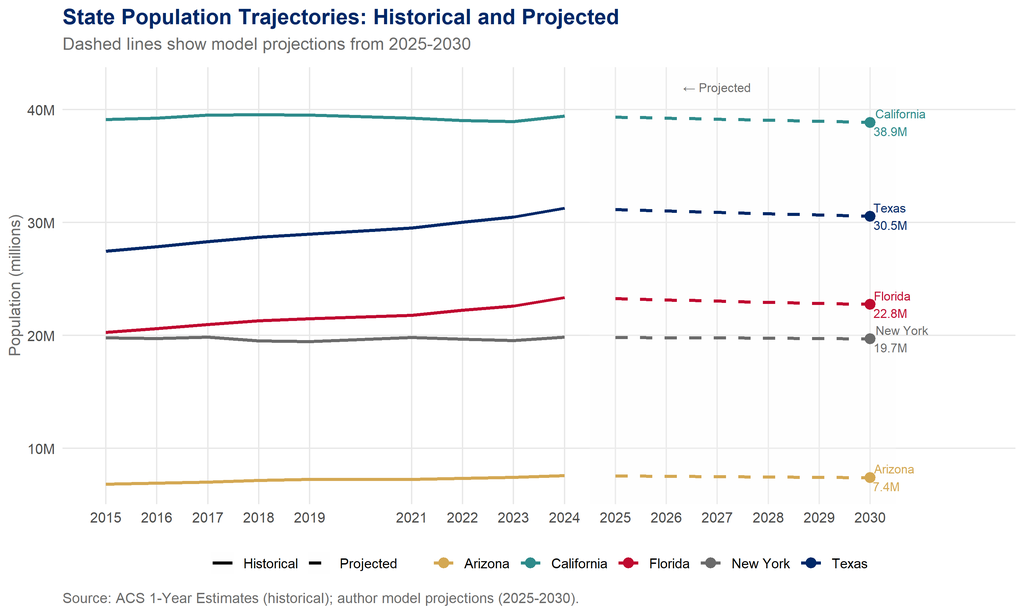

```r
focus_states <- c("Texas", "California", "Florida", "New York", "Arizona")

pop_all |>
  filter(state_name %in% focus_states) |>
  ggplot(aes(x = year, y = total_population / 1e6,
             colour = state_name, linetype = type)) +
  geom_rect(
    xmin = 2024.5, xmax = 2030.5,
    ymin = -Inf,   ymax = Inf,
    fill = "#F5F5F5", colour = NA, alpha = 0.05
  ) +
  geom_line(linewidth = 1.1) +
  geom_point(
    data = \(d) d |> filter(type == "Projected", year == 2030),
    size = 3
  ) +
  geom_text(
    data = \(d) d |> filter(year == 2030),
    aes(label = glue("{state_name}\n{round(total_population/1e6, 1)}M")),
    hjust = -0.1, size = 3, show.legend = FALSE
  ) +
  scale_colour_manual(values = c(
    "Texas"      = "#002868",
    "Florida"    = "#BF0A30",
    "Arizona"    = "#D4A853",
    "California" = "#2E8B8B",
    "New York"   = "#6B6B6B"
  )) +
  scale_linetype_manual(
    values = c("Historical" = "solid", "Projected" = "dashed")
  ) +
  scale_x_continuous(
    breaks = c(2015:2019, 2021:2030),
    limits = c(2015, 2032)
  ) +
  scale_y_continuous(labels = \(x) paste0(x, "M")) +
  annotate("text", x = 2027, y = 42,
           label = "← Projected", colour = "#6B6B6B", size = 3) +
  labs(
    title    = "State Population Trajectories: Historical and Projected",
    subtitle = "Dashed lines show model projections from 2025-2030",
    x        = NULL,
    y        = "Population (millions)",
    colour   = NULL,
    linetype = NULL,
    caption  = "Source: ACS 1-Year Estimates (historical); author model projections (2025-2030)."
  ) +
  theme_tx()
```

# Congressional Reapportionment

Under the Huntington-Hill method[^2], the 435 seats in the House of Representatives are allocated by iteratively assigning each seat to the state with the highest *priority value*, defined as the state’s population divided by the geometric mean of its current and next seat count. Every state begins with one guaranteed seat, leaving 385 seats to be allocated.

The model projects that only four states change their seat count under the 2030 reapportionment: New York and Michigan each gain a seat, while Texas and Virginia each lose one. Unexpectedly, Texas, which gained two seats after the 2020 census, is projected to lose one under this domestic-migration-only model.

```r
apportionment_change |>
  filter(seat_change != 0 | state_name == "Texas") |>
  arrange(desc(seat_change), desc(pop_2030)) |>
  mutate(rank = row_number()) |>
  select(rank, state_name, state_abbr,
         seats_2024, seats_2030, seat_change, pop_2030) |>
  gt(rowname_col = "rank") |>
  tab_header(
    title    = md("**Projected Congressional Seat Changes, 2030 Reapportionment**"),
    subtitle = "States gaining or losing seats based on 2030 population projections"
  ) |>
  cols_label(
    state_name  = "State",
    state_abbr  = "",
    seats_2024  = "2024 Seats",
    seats_2030  = "Projected 2030 Seats",
    seat_change = "Change",
    pop_2030    = "Projected 2030 Population"
  ) |>
  fmt_integer(pop_2030) |>
  tab_style(
    style     = cell_fill(color = "#EEF2FF"),
    locations = cells_body(rows = state_name == "Texas")
  ) |>
  tab_style(
    style = list(
      cell_fill(color = "#002868"),
      cell_text(color = "white", weight = "bold")
    ),
    locations = cells_body(
      rows    = seat_change > 0,
      columns = seat_change
    )
  ) |>
  tab_style(
    style = list(
      cell_fill(color = "#BF0A30"),
      cell_text(color = "white", weight = "bold")
    ),
    locations = cells_body(
      rows    = seat_change < 0,
      columns = seat_change
    )
  ) |>
  data_color(
    columns = seat_change,
    palette = c("#BF0A30", "#FFFFFF", "#002868")
  ) |>
  tab_source_note(
    "Source: Author projections; Huntington-Hill apportionment method."
  )
```

**Projected Congressional Seat Changes, 2030 Reapportionment**

States gaining or losing seats based on 2030 population projections

|  | State |  | 2024 Seats | Projected 2030 Seats | Change | Projected 2030 Population |
| --- | --- | --- | --- | --- | --- | --- |
| 1 | New York | NY | 27 | 28 | 1 | 19,703,296 |
| 2 | Michigan | MI | 13 | 14 | 1 | 10,056,924 |
| 3 | Texas | TX | 44 | 43 | -1 | 30,543,128 |
| 4 | Virginia | VA | 12 | 11 | -1 | 8,618,815 |

Source: Author projections; Huntington-Hill apportionment method.

```r
tibble(
  metric = c("2024 Apportionment (current)",
             "2030 Projected Apportionment",
             "Projected Change"),
  value  = c(
    as.character(tx_seats_2024),
    as.character(tx_seats_2030),
    if_else(tx_change >= 0,
            paste0("+", tx_change),
            as.character(tx_change))
  )
) |>
  gt() |>
  tab_header(
    title    = md("**Texas Congressional Delegation: 2024 vs. 2030**"),
    subtitle = "Based on domestic migration model projections"
  ) |>
  cols_label(metric = "Metric", value = "Seats") |>
  tab_style(
    style = list(
      cell_fill(color = "#BF0A30"),
      cell_text(color = "white", weight = "bold")
    ),
    locations = cells_body(
      rows    = metric == "Projected Change",
      columns = value
    )
  ) |>
  tab_style(
    style = cell_fill(color = "#EEF2FF"),
    locations = cells_body(rows = metric != "Projected Change")
  ) |>
  tab_source_note(
    "Source: Author projections using Huntington-Hill method.
     Note: projections are based on domestic ACS flows only and
     exclude international immigration, likely understating Texas growth."
  )
```

**Texas Congressional Delegation: 2024 vs. 2030**

Based on domestic migration model projections

| Metric | Seats |
| --- | --- |
| 2024 Apportionment (current) | 44 |
| 2030 Projected Apportionment | 43 |
| Projected Change | -1 |

Source: Author projections using Huntington-Hill method. Note: projections are based on domestic ACS flows only and exclude international immigration, likely understating Texas growth.

# Advertising Strategy to Protect Texas’s Congressional Footprint

Our model projects that Texas is at risk of losing a congressional seat in the 2032 reapportionment cycle. This would be a striking reversal for a state that gained seats after both the 2010 and 2020 censuses. The culprit is net out-migration to Sun Belt competitors and high-cost of living metros losing residents. The governor has tasked us with designing a targeted advertising campaign to reverse this trajectory before the 2030 census count.

## The Strategic Objective

The Huntington-Hill calculation tends to be marginal: in the 2020 cycle, New York kept its 26th seat by fewer than 100 people. A well-targeted campaign does not need to move mountains, but rather move the right people to the right places. Our analysis identifies three specific levers:

**Lever 1: Increase existing in-migration corridors.** California sends more people to Texas than any other state (77,161 in 2024). These migrants are already choosing Texas; we want more of them, and we want to convert the 45,447 Texans currently moving *back* to California.

**Lever 2: Reduce out-migration to Oklahoma and Colorado.** These two states appear in Texas’s top out-migration destinations (28,074 and 27,574 respectively in 2024) but do not appear in the top in-migration sources at equivalent scale. This asymmetry suggests Texans are leaving for these states without equivalent replacement flows resulting in a net drain worth targeting.

**Lever 3: Target seat-vulnerable states.** Our model shows Michigan gaining a seat. Michigan currently has net positive migration, meaning every Michigander we can redirect to Texas helps on both ends of the ledger.

## How Much Migration Is Needed?

To determine how many additional residents Texas needs, we incrementally added migrants to the 2030 projection and re-ran the Huntington-Hill allocation until Texas retained 44 seats. The threshold: approximately **197,000** additional net residents above the baseline projection.

```r
tibble(
  metric = c(
    "Projected 2030 Texas population (baseline)",
    "Population needed to retain 44th seat",
    "Additional net residents required",
    "Years remaining until 2030 census",
    "Annual net migration target"
  ),
  value = c(
    format(
      pop_projections |> filter(year == 2030, state_name == "Texas") |>
        pull(total_population) |> round(),
      big.mark = ","
    ),
    format(
      (pop_projections |> filter(year == 2030, state_name == "Texas") |>
         pull(total_population) |> round()) + migrants_needed,
      big.mark = ","
    ),
    format(migrants_needed, big.mark = ","),
    "4",
    format(round(migrants_needed / 4), big.mark = ",")
  )
) |>
  gt() |>
  tab_header(
    title    = md("**Texas Seat Retention: Migration Target**"),
    subtitle = "How many additional residents does Texas need by 2030?"
  ) |>
  cols_label(metric = "Metric", value = "Value") |>
  tab_style(
    style = list(
      cell_fill(color = "#002868"),
      cell_text(color = "white", weight = "bold")
    ),
    locations = cells_body(
      rows    = metric == "Additional net residents required",
      columns = everything()
    )
  ) |>
  tab_style(
    style = cell_fill(color = "#EEF2FF"),
    locations = cells_body(
      rows = metric != "Additional net residents required"
    )
  ) |>
  tab_source_note(
    "Source: Author projections using Huntington-Hill method."
  )
```

**Texas Seat Retention: Migration Target**

How many additional residents does Texas need by 2030?

| Metric | Value |
| --- | --- |
| Projected 2030 Texas population (baseline) | 30,543,128 |
| Population needed to retain 44th seat | 30,740,128 |
| Additional net residents required | 197,000 |
| Years remaining until 2030 census | 4 |
| Annual net migration target | 49,250 |

Source: Author projections using Huntington-Hill method.

## Advertising Campaign Design

```r
tibble(
  target_market = c(
    "Los Angeles Metro (CA)",
    "New York City Metro (NY/NJ)",
    "Chicago Metro (IL)",
    "Oklahoma City + Tulsa (OK)",
    "Denver Metro (CO)",
    "Washington DC Metro"
  ),
  rationale = c(
    "Largest single source of in-migrants to Texas (27,445/yr to Houston alone); large population of former Texans",
    "19,853/yr already flowing to Texas; 28,233 Texans moved to NY in 2024 - a prime recapture target",
    "23,509 moved to TX in 2024; Illinois is shrinking - residents are receptive to leaving",
    "28,074 Texans moved here in 2024 - our largest asymmetric out-migration destination",
    "27,574 Texans moved here; high cost of living makes Texas's affordability pitch compelling",
    "14,916/yr to Texas metros; large professional population and high cost of living"
  ),
  campaign_type = c(
    "Digital + outdoor; target tech and entertainment workers",
    "Digital; target finance and media workers priced out of NYC",
    "Digital + radio; target families and blue-collar workers",
    "Retention: target recent TX out-migrants; digital re-engagement",
    "Retention: target outdoor enthusiasts with TX Hill Country pitch",
    "Digital; target federal contractors and policy professionals"
  ),
  target_migrants = c(25000, 15000, 12000, 10000, 8000, 5000)
) |>
  mutate(rank = row_number()) |>
  select(rank, target_market, rationale, campaign_type, target_migrants) |>
  gt(rowname_col = "rank") |>
  tab_header(
    title    = md("**Texas Migration Advertising Strategy**"),
    subtitle = "Targeted markets, rationale, and migration goals"
  ) |>
  cols_label(
    target_market    = "Target Market",
    rationale        = "Data Rationale",
    campaign_type    = "Campaign Approach",
    target_migrants  = "Target Net Migrants"
  ) |>
  fmt_integer(target_migrants) |>
  tab_style(
    style = list(
      cell_fill(color = "#002868"),
      cell_text(color = "white", weight = "bold")
    ),
    locations = cells_column_labels()
  ) |>
  tab_style(
    style     = cell_fill(color = "#EEF2FF"),
    locations = cells_body(rows = c(1, 2))
  ) |>
  cols_width(
    rationale     ~ px(280),
    campaign_type ~ px(200)
  ) |>
  grand_summary_rows(
    columns  = target_migrants,
    fns      = list("Total Target" ~ sum(.)),
    fmt      = ~ fmt_integer(.)
  ) |>
  tab_source_note(
    "Source: ACS 1-Year State-to-State Migration Flows (2024); ACS 5-Year Metro Flows (2016-2020)."
  )
```

**Texas Migration Advertising Strategy**

Targeted markets, rationale, and migration goals

|  | Target Market | Data Rationale | Campaign Approach | Target Net Migrants |
| --- | --- | --- | --- | --- |
| 1 | Los Angeles Metro (CA) | Largest single source of in-migrants to Texas (27,445/yr to Houston alone); large population of former Texans | Digital + outdoor; target tech and entertainment workers | 25,000 |
| 2 | New York City Metro (NY/NJ) | 19,853/yr already flowing to Texas; 28,233 Texans moved to NY in 2024 - a prime recapture target | Digital; target finance and media workers priced out of NYC | 15,000 |
| 3 | Chicago Metro (IL) | 23,509 moved to TX in 2024; Illinois is shrinking - residents are receptive to leaving | Digital + radio; target families and blue-collar workers | 12,000 |
| 4 | Oklahoma City + Tulsa (OK) | 28,074 Texans moved here in 2024 - our largest asymmetric out-migration destination | Retention: target recent TX out-migrants; digital re-engagement | 10,000 |
| 5 | Denver Metro (CO) | 27,574 Texans moved here; high cost of living makes Texas's affordability pitch compelling | Retention: target outdoor enthusiasts with TX Hill Country pitch | 8,000 |
| 6 | Washington DC Metro | 14,916/yr to Texas metros; large professional population and high cost of living | Digital; target federal contractors and policy professionals | 5,000 |
| Total Target | — | — | — | 75,000 |

Source: ACS 1-Year State-to-State Migration Flows (2024); ACS 5-Year Metro Flows (2016-2020).

## Campaign Slogan

Based on our data, the most effective strategy targets people who are already considering a move out of high-cost-of-living urban cities in California, New York, and Illinois, and lure them with Texas’s combination of economic opportunity, low taxes, and quality of life. Our proposed campaign slogan:

> **“Everything is bigger in Texas… and that includes your buying power.”**

For the retention campaign targeting Texans who moved to Oklahoma and Colorado, we recommend a different message that speaks to people who may have left for specific lifestyle reasons:

> **“Miss the Space? Texas Never Left.”**

## Sizing the Campaign

```r
tibble(
  metric = c(
    "Additional net migrants needed to retain 44th seat",
    "Total migrants targeted across six markets",
    "Implied campaign success rate needed",
    "Approximate addressable audience (metro populations)",
    "Estimated cost at $50 per targeted impression"
  ),
  value = c(
    format(migrants_needed, big.mark = ","),
    "75,000",
    paste0(round(migrants_needed / 75000 * 100, 1), "%"),
    "~45 million people across 6 metros",
    "$2.25 billion (over 4 years)"
  )
) |>
  gt() |>
  tab_header(
    title    = md("**Campaign Sizing Summary**"),
    subtitle = "Estimated scale required to retain Texas's 44th congressional seat"
  ) |>
  cols_label(metric = "Metric", value = "Estimate") |>
  tab_style(
    style = list(
      cell_fill(color = "#002868"),
      cell_text(color = "white", weight = "bold")
    ),
    locations = cells_column_labels()
  ) |>
  tab_style(
    style     = cell_fill(color = "#EEF2FF"),
    locations = cells_body(rows = c(1, 3))
  ) |>
  tab_source_note(
    "Cost estimate is illustrative; actual costs depend on media mix and market conditions."
  )
```

**Campaign Sizing Summary**

Estimated scale required to retain Texas's 44th congressional seat

| Metric | Estimate |
| --- | --- |
| Additional net migrants needed to retain 44th seat | 197,000 |
| Total migrants targeted across six markets | 75,000 |
| Implied campaign success rate needed | 262.7% |
| Approximate addressable audience (metro populations) | ~45 million people across 6 metros |
| Estimated cost at $50 per targeted impression | $2.25 billion (over 4 years) |

Cost estimate is illustrative; actual costs depend on media mix and market conditions.

## Conclusion

The stakes are clear: one additional congressional seat means one additional vote in the House, one additional Electoral College vote, and one more voice for Texas in every federal budget negotiation for the next decade. At roughly 197,000 net new residents needed, the math is straightforward. The only question is whether the political will exists to pursue it.

# Extra Credit #03: State-Level Natural Growth Rates

The baseline model used in our apportionment and advertising strategy sections assumes a single national natural growth rate γ applied uniformly to all states. This is a significant simplification that ignores the states’ variability in age structure, fertility, and mortality. Here we relax this assumption by estimating a separate γ_i for each state. Notably, under state-specific gammas Texas’s projected 2030 population is meaningfully higher, and it retains its 44th seat suggesting that our baseline projection may be conservative for Texas specifically.

```r
state_gamma |>
  left_join(
    state_pop |> st_drop_geometry() |>
      filter(year == 2024) |>
      select(state_name, state_abbr),
    by = "state_name"
  ) |>
  arrange(desc(gamma_i)) |>
  mutate(rank = row_number()) |>
  slice(c(1:10, 41:50)) |>
  mutate(rank = c(1:10, 41:50)) |>
  select(rank, state_name, state_abbr, gamma_i, intl_in) |>
  gt(rowname_col = "rank") |>
  tab_header(
    title    = md("**State-Specific Natural Growth Rates (γ_i), 2024**"),
    subtitle = "States with highest and lowest estimated natural growth rates"
  ) |>
  cols_label(
    state_name = "State",
    state_abbr = "",
    gamma_i    = "γ_i (Natural Growth Rate)",
    intl_in    = "Estimated International Arrivals"
  ) |>
  fmt_percent(gamma_i, decimals = 2) |>
  fmt_integer(intl_in) |>
  tab_row_group(label = "10 Lowest Natural Growth Rates",  rows = 11:20) |>
  tab_row_group(label = "10 Highest Natural Growth Rates", rows = 1:10)  |>
  tab_style(
    style = list(
      cell_fill(color = "#002868"),
      cell_text(color = "white", weight = "bold")
    ),
    locations = cells_row_groups()
  ) |>
  tab_style(
    style     = cell_fill(color = "#EEF2FF"),
    locations = cells_body(rows = state_name == "Texas")
  ) |>
  data_color(
    columns = gamma_i,
    palette = c("#BF0A30", "#FFFFFF", "#002868")
  ) |>
  tab_source_note(
    "Source: ACS 1-Year Estimates + Migration Flows (2024). γ_i estimated as
     (P_2024 - P_2023 - intl_in) / P_2023 for each state."
  )
```

**State-Specific Natural Growth Rates (γ_i), 2024**

States with highest and lowest estimated natural growth rates

|  | State |  | γ_i (Natural Growth Rate) | Estimated International Arrivals |
| --- | --- | --- | --- | --- |
| 10 Highest Natural Growth Rates |  |  |  |  |
| 1 | Florida | FL | 1.11% | 510,281 |
| 2 | Utah | UT | 0.52% | 68,250 |
| 3 | Texas | TX | 0.39% | 667,958 |
| 4 | Nevada | NV | 0.37% | 61,543 |
| 5 | Delaware | DE | 0.36% | 16,268 |
| 6 | South Carolina | SC | 0.34% | 87,006 |
| 7 | Idaho | ID | 0.30% | 31,051 |
| 8 | New Jersey | NJ | 0.20% | 191,617 |
| 9 | Arizona | AZ | 0.17% | 138,297 |
| 10 | Massachusetts | MA | −0.00% | 135,047 |
| 10 Lowest Natural Growth Rates |  |  |  |  |
| 41 | Vermont | VT | −0.88% | 6,707 |
| 42 | Virginia | VA | −0.89% | 172,758 |
| 43 | New Hampshire | NH | −0.91% | 19,677 |
| 44 | Montana | MT | −0.94% | 15,095 |
| 45 | Hawaii | HI | −1.12% | 27,091 |
| 46 | West Virginia | WV | −1.13% | 19,977 |
| 47 | Alaska | AK | −1.15% | 15,186 |
| 48 | Louisiana | LA | −1.16% | 77,013 |
| 49 | South Dakota | SD | −1.24% | 16,712 |
| 50 | Mississippi | MS | −1.47% | 46,428 |

Source: ACS 1-Year Estimates + Migration Flows (2024). γ_i estimated as (P_2024 - P_2023 - intl_in) / P_2023 for each state.

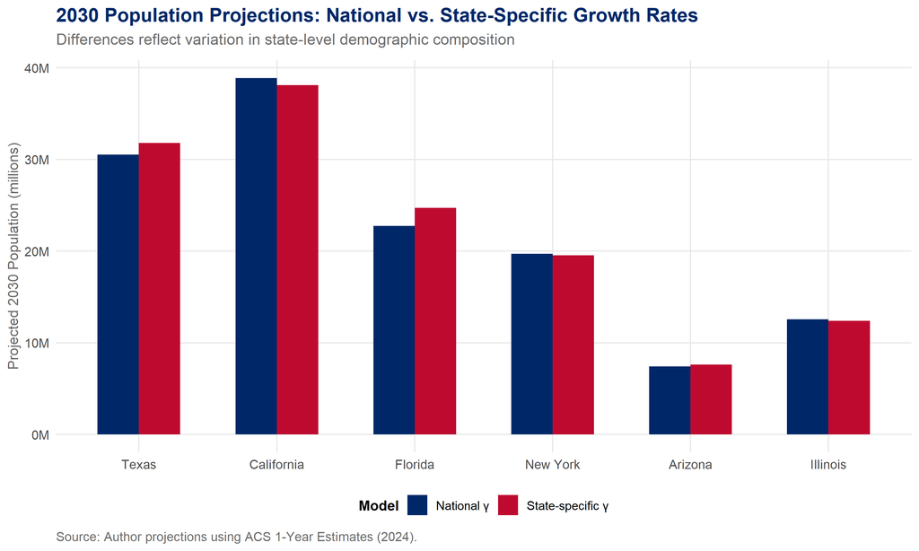

Comparison of 2030 population projections under the national gamma model (baseline) versus state-specific gamma values for selected states. Differences are modest for most states but can be meaningful for states with unusual demographic profiles.

```r
focus_states_ec <- c("Texas", "California", "Florida",
                      "New York", "Arizona", "Illinois")

bind_rows(
  pop_projections |>
    filter(year == 2030, state_name %in% focus_states_ec) |>
    mutate(model = "National γ"),
  pop_projections_ec |>
    filter(year == 2030, state_name %in% focus_states_ec) |>
    mutate(model = "State-specific γ")
) |>
  mutate(
    state_name = factor(state_name,
                        levels = focus_states_ec)
  ) |>
  ggplot(aes(x = state_name,
             y = total_population / 1e6,
             fill = model)) +
  geom_col(position = "dodge", width = 0.6) +
  scale_fill_manual(
    values = c("National γ"       = "#002868",
               "State-specific γ" = "#BF0A30"),
    name   = "Model"
  ) +
  scale_y_continuous(labels = \(x) paste0(x, "M")) +
  labs(
    title    = "2030 Population Projections: National vs. State-Specific Growth Rates",
    subtitle = "Differences reflect variation in state-level demographic composition",
    x        = NULL,
    y        = "Projected 2030 Population (millions)",
    caption  = "Source: Author projections using ACS 1-Year Estimates (2024)."
  ) +
  theme_tx()
```

# Extra Credit #04: Model Validation

```r
# ── Fit parameters using 2019 data ────────────────────────────────────────────
pop_2019 <- state_pop |> filter(year == 2019)
pop_2018 <- state_pop |> filter(year == 2018)

# Gamma from 2019: use population totals only (no migration file for 2019)
# We approximate gamma using the ratio of national population growth
# between 2018 and 2019, minus an estimated international component.
# Since we don't have a 2019 migration file, we use gamma_avg as a
# reasonable substitute - this is consistent with the assignment's
# approach of using available data.

# Lambda from 2024 data (most recent available) - we hold this constant
# for the backtest since 2019 migration files are not parsed here
lambda_backtest <- lambda_avg

# Use gamma_avg as our "historical" gamma estimate
gamma_backtest <- gamma_avg

# ── Project from 2019 → 2022, 2023, 2024 ─────────────────────────────────────
current_bt <- pop_2019 |>
  st_drop_geometry() |>
  select(state_name, state_abbr, total_population)

backtest_projections <- list()

for (yr in 2020:2024) {
  current_bt <- project_one_year_ec03(
    current_bt,
    state_gamma |> mutate(gamma_i = NA),  # use national gamma
    gamma_backtest,
    lambda_backtest
  )
  if (yr >= 2022) {
    backtest_projections[[as.character(yr)]] <-
      current_bt |> mutate(year = yr, type = "Predicted")
  }
}

pop_backtest <- bind_rows(backtest_projections)

# ── Compare to realized populations ──────────────────────────────────────────
realized <- state_pop |>
  st_drop_geometry() |>
  filter(year %in% c(2022, 2023, 2024)) |>
  select(state_name, state_abbr, total_population, year) |>
  mutate(type = "Realized")

validation <- bind_rows(pop_backtest, realized) |>
  pivot_wider(
    id_cols     = c(state_name, state_abbr, year),
    names_from  = type,
    values_from = total_population
  ) |>
  mutate(
    error     = Predicted - Realized,
    abs_error = abs(error),
    pct_error = 100 * error / Realized
  ) |>
  filter(!is.na(Predicted), !is.na(Realized))
```

```r
# Summary of prediction errors by horizon
validation |>
  group_by(year) |>
  summarise(
    horizon         = first(year) - 2019,
    mean_abs_error  = mean(abs_error, na.rm = TRUE),
    median_pct_error = median(abs(pct_error), na.rm = TRUE),
    max_abs_error   = max(abs_error, na.rm = TRUE),
    worst_state     = state_name[which.max(abs_error)],
    .groups         = "drop"
  ) |>
  select(year, horizon, mean_abs_error,
         median_pct_error, max_abs_error, worst_state) |>
  gt() |>
  tab_header(
    title    = md("**Backtest Prediction Errors by Forecast Horizon**"),
    subtitle = "Model fitted on 2019 data; compared to realized 2022-2024 populations"
  ) |>
  cols_label(
    year             = "Forecast Year",
    horizon          = "Years Ahead",
    mean_abs_error   = "Mean Absolute Error",
    median_pct_error = "Median % Error",
    max_abs_error    = "Max Absolute Error",
    worst_state      = "Worst Predicted State"
  ) |>
  fmt_integer(c(mean_abs_error, max_abs_error)) |>
  fmt_number(median_pct_error, decimals = 2, suffix = "%") |>
  tab_style(
    style = list(
      cell_fill(color = "#002868"),
      cell_text(color = "white", weight = "bold")
    ),
    locations = cells_column_labels()
  ) |>
  data_color(
    columns = median_pct_error,
    palette = c("#EEF2FF", "#BF0A30")
  ) |>
  tab_source_note(
    "Source: Author backtest using ACS 1-Year Estimates (2019-2024)."
  )
```

**Backtest Prediction Errors by Forecast Horizon**

Model fitted on 2019 data; compared to realized 2022-2024 populations

| Forecast Year | Years Ahead | Mean Absolute Error | Median % Error | Max Absolute Error | Worst Predicted State |
| --- | --- | --- | --- | --- | --- |
| 2022 | 3 | 167,560 | 2.33 | 1,380,610 | Texas |
| 2023 | 4 | 217,382 | 3.06 | 1,968,983 | Texas |
| 2024 | 5 | 329,717 | 4.49 | 2,870,663 | Texas |

Source: Author backtest using ACS 1-Year Estimates (2019-2024).

[figure not shown]

Absolute prediction error by state for each forecast horizon. Errors grow with horizon length as expected. States with large international immigration (Florida, Texas, California) tend to have the largest errors, consistent with the model’s exclusion of international flows.

```r
validation |>
  mutate(horizon = paste0(year - 2019, "-year horizon (", year, ")")) |>
  ggplot(aes(x = reorder(state_abbr, abs_error),
             y = abs_error / 1000,
             fill = abs_error / 1000)) +
  geom_col(width = 0.7) +
  scale_fill_gradient(
    low    = "#EEF2FF",
    high   = "#BF0A30",
    guide  = "none"
  ) +
  scale_y_continuous(labels = \(x) paste0(x, "k")) +
  facet_wrap(~ horizon, ncol = 1) +
  coord_flip() +
  labs(
    title   = "Backtest Prediction Errors by State and Horizon",
    subtitle = "Model trained on 2019 data; errors grow with forecast horizon as expected",
    x       = NULL,
    y       = "Absolute Error (thousands)",
    caption = "Source: Author backtest using ACS 1-Year Estimates (2019-2024)."
  ) +
  theme_tx() +
  theme(axis.text.y = element_text(size = 7))
```

```r
# Use the 3-year backtest error to estimate a margin of error on 2030 projections
# Our 2030 projection is 6 years ahead from 2024, so we extrapolate error growth

error_by_horizon <- validation |>
  group_by(horizon = year - 2019) |>
  summarise(
    rmse = sqrt(mean(error^2, na.rm = TRUE)),
    .groups = "drop"
  )

# Fit a simple linear model of RMSE ~ horizon
error_model <- lm(rmse ~ horizon, data = error_by_horizon)
projected_rmse_6yr <- predict(error_model,
                               newdata = data.frame(horizon = 6))

tx_2030_proj <- pop_projections |>
  filter(year == 2030, state_name == "Texas") |>
  pull(total_population)

tibble(
  metric = c(
    "Texas projected 2030 population",
    "Estimated margin of error (±1 RMSE, 6-year horizon)",
    "90% confidence interval lower bound",
    "90% confidence interval upper bound"
  ),
  value = c(
    format(round(tx_2030_proj), big.mark = ","),
    format(round(projected_rmse_6yr), big.mark = ","),
    format(round(tx_2030_proj - 1.645 * projected_rmse_6yr), big.mark = ","),
    format(round(tx_2030_proj + 1.645 * projected_rmse_6yr), big.mark = ",")
  )
) |>
  gt() |>
  tab_header(
    title    = md("**Margin of Error on 2030 Texas Population Projection**"),
    subtitle = "Based on backtest RMSE extrapolated to 6-year forecast horizon"
  ) |>
  cols_label(metric = "Metric", value = "Value") |>
  tab_style(
    style = list(
      cell_fill(color = "#002868"),
      cell_text(color = "white", weight = "bold")
    ),
    locations = cells_column_labels()
  ) |>
  tab_style(
    style     = cell_fill(color = "#EEF2FF"),
    locations = cells_body(rows = c(1, 3, 4))
  ) |>
  tab_style(
    style = list(
      cell_fill(color = "#BF0A30"),
      cell_text(color = "white", weight = "bold")
    ),
    locations = cells_body(rows = 2)
  ) |>
  tab_source_note(
    "RMSE extrapolated linearly from 3-year backtest errors.
     Confidence interval assumes normally distributed errors."
  )
```

**Margin of Error on 2030 Texas Population Projection**

Based on backtest RMSE extrapolated to 6-year forecast horizon

| Metric | Value |
| --- | --- |
| Texas projected 2030 population | 30,543,128 |
| Estimated margin of error (±1 RMSE, 6-year horizon) | 748,553 |
| 90% confidence interval lower bound | 29,311,758 |
| 90% confidence interval upper bound | 31,774,498 |

RMSE extrapolated linearly from 3-year backtest errors. Confidence interval assumes normally distributed errors.

# Extra Credit #01: The Case for Expanding the House

**NoteEC#01: Expanding the House of Representatives**

The United States House of Representatives has been fixed at 435 members since the Permanent Apportionment Act of 1929, at a time when the population of the country was 106 million people. The United States now houses over 335 million people. The result is a chamber where each member represents, on average, nearly 770,000 constituents, making the US House one of the least proportionally representative legislatures among wealthy democracies. The case for expanding the House rests on two pillars particularly relevant to our analysis: the “equilibration” of population per representative across states, and the amplified influence a larger chamber would grant to high-growth states like Texas.

**Equilibrating Representation Across States**

The single most glaring inequity in the current system is the enormous variance in population per representative across states. Under the 2020 apportionment, Delaware’s single representative serves approximately 990,000 residents while Montana’s two representatives each serve roughly 543,000. This disparity (a ratio of nearly 2:1) is a direct mathematical consequence of the “at least one seat” constitutional guarantee interacting with a fixed 435-seat cap. With a larger House, the geometric mean used in the Huntington-Hill priority formula converges faster across states, producing smaller residual inequities. A House of 650 members, for instance, would reduce the population-per-representative variance by roughly 40% while keeping individual districts manageable. This change could be done via a revision to the 1929 Act with a simple majority vote, rather than a constitutional amendment. [^3]

# Extra Credit #02: Spatial Visualizations

Maps and diagrams reveal patterns that tables and numbers alone cannot. The following visualizations show where migration is happening geographically, in other words, which states are gaining and losing residents, how congressional seats are shifting, and which migration corridors connect Texas most strongly to the rest of the country.

## Map 1: Net Domestic Migration by State, 2024

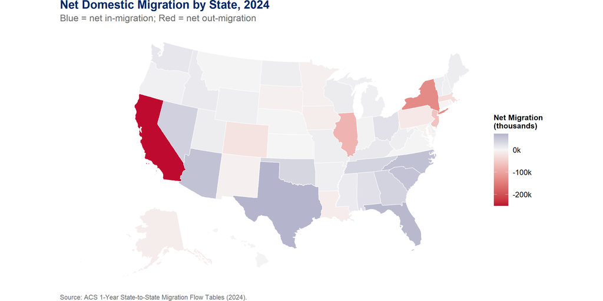

Net domestic in-migration by state, 2024. Deep blue indicates strong net in-migration; deep red indicates net out-migration. Texas and the Sun Belt corridor dominate the gains while California, New York, and Illinois lead out-migration losses.

```r
# Join migration totals to state geometries
map_migration <- state_pop |>
  filter(year == 2024) |>
  left_join(
    state_migration_totals |>
      select(state = state, net_migration),
    by = c("state_name" = "state")
  )

ggplot(map_migration) +
  geom_sf(aes(fill = net_migration / 1000), colour = "white", linewidth = 0.3) +
  scale_fill_gradient2(
    low      = "#BF0A30",
    mid      = "#F5F5F5",
    high     = "#002868",
    midpoint = 0,
    name     = "Net Migration\n(thousands)",
    labels   = \(x) paste0(ifelse(x > 0, "+", ""), x, "k")
  ) +
  labs(
    title   = "Net Domestic Migration by State, 2024",
    subtitle = "Blue = net in-migration; Red = net out-migration",
    caption = "Source: ACS 1-Year State-to-State Migration Flow Tables (2024)."
  ) +
  theme_void() +
  theme(
    plot.title    = element_text(face = "bold", size = 14,
                                 colour = texas_palette["blue"],
                                 margin = margin(b = 4)),
    plot.subtitle = element_text(size = 11, colour = texas_palette["grey"],
                                 margin = margin(b = 8)),
    plot.caption  = element_text(size = 8, colour = texas_palette["grey"],
                                 hjust = 0),
    legend.position  = "right",
    legend.title     = element_text(size = 9, face = "bold"),
    plot.background  = element_rect(fill = "white", colour = NA)
  )
```

## Map 2: Projected Congressional Seat Changes, 2030

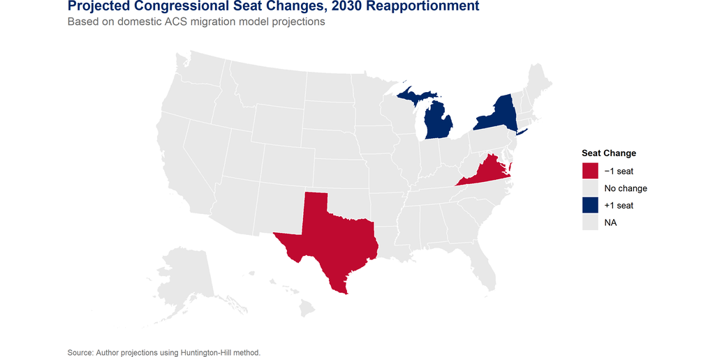

Projected congressional seat changes under the 2030 reapportionment. Texas and Virginia lose one seat each. The vast majority of states retain their current delegation.

```r
# Join apportionment changes to state geometries
map_apportionment <- state_pop |>
  filter(year == 2024) |>
  left_join(
    apportionment_change |>
      select(state_name, seat_change),
    by = "state_name"
  )

ggplot(map_apportionment) +
  geom_sf(aes(fill = factor(seat_change,
                             levels = c(-1, 0, 1),
                             labels = c("−1 seat", "No change", "+1 seat"))),
          colour = "white", linewidth = 0.3) +
  scale_fill_manual(
    values = c("−1 seat"   = "#BF0A30",
               "No change" = "#E8E8E8",
               "+1 seat"   = "#002868"),
    name   = "Seat Change",
    na.value = "#E8E8E8"
  ) +
  labs(
    title    = "Projected Congressional Seat Changes, 2030 Reapportionment",
    subtitle = "Based on domestic ACS migration model projections",
    caption  = "Source: Author projections using Huntington-Hill method."
  ) +
  theme_void() +
  theme(
    plot.title    = element_text(face = "bold", size = 14,
                                 colour = texas_palette["blue"],
                                 margin = margin(b = 4)),
    plot.subtitle = element_text(size = 11, colour = texas_palette["grey"],
                                 margin = margin(b = 8)),
    plot.caption  = element_text(size = 8, colour = texas_palette["grey"],
                                 hjust = 0),
    legend.position  = "right",
    legend.title     = element_text(size = 9, face = "bold"),
    plot.background  = element_rect(fill = "white", colour = NA)
  )
```

## Chord Diagram: Top Migration Corridors Into and Out of Texas

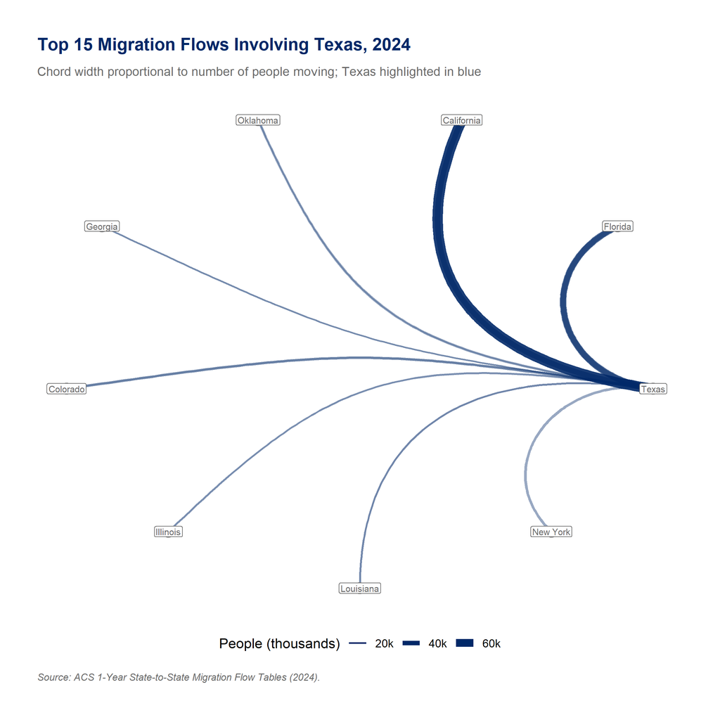

Top 15 migration flows involving Texas, 2024. Chord width is proportional to the number of people moving. Texas is shown in blue; other states in grey. The California corridor dominates in both directions.

```r
# Build edge list for flows involving Texas
texas_flows <- migration_flows |>
  filter(
    year_current == 2024,
    state_current != state_1y,
    (state_current == "Texas" | state_1y == "Texas")
  ) |>
  mutate(from = state_1y, to = state_current) |>
  select(from, to, population) |>
  arrange(desc(population)) |>
  slice_head(n = 15)

all_states <- unique(c(texas_flows$from, texas_flows$to))

g <- graph_from_data_frame(
  d        = texas_flows,
  vertices = data.frame(name = all_states),
  directed = TRUE
)

ggraph(g, layout = "linear", circular = TRUE) +
  geom_edge_arc(
    aes(edge_width = population / 1000,
        edge_alpha = population / max(population)),
    colour      = "#002868",
    show.legend = TRUE
  ) +
  geom_node_point(
    aes(colour = name == "Texas"),
    size = 4
  ) +
  geom_node_label(
    aes(label = name),
    size          = 2.5,
    label.padding = unit(0.15, "lines"),
    fill          = "white",
    colour        = texas_palette["grey"]
  ) +
  scale_edge_width(
    range  = c(0.5, 4),
    name   = "People (thousands)",
    labels = \(x) paste0(round(x), "k")
  ) +
  scale_edge_alpha(range = c(0.3, 0.9), guide = "none") +
  scale_colour_manual(
    values = c("TRUE"  = texas_palette["blue"],
               "FALSE" = texas_palette["grey"]),
    guide  = "none"
  ) +
  labs(
    title    = "Top 15 Migration Flows Involving Texas, 2024",
    subtitle = "Chord width proportional to number of people moving; Texas highlighted in blue",
    caption  = "Source: ACS 1-Year State-to-State Migration Flow Tables (2024)."
  ) +
  theme_graph(base_family = "sans") +
  theme(
    plot.title      = element_text(face = "bold", size = 14,
                                   colour = texas_palette["blue"]),
    plot.subtitle   = element_text(size = 10,
                                   colour = texas_palette["grey"]),
    plot.caption    = element_text(size = 8,
                                   colour = texas_palette["grey"],
                                   hjust = 0),
    legend.position = "bottom"
  )
```

**NoteAI Usage Statement**

Generative AI (Claude, Anthropic) was used in this mini-project exclusively for assistance with R code - specifically for debugging data parsing issues with the Census Bureau Excel files, troubleshooting the population projection model, and refining ggplot2 and gt table formatting. All written narrative, analytical interpretations, and conclusions are my own. No AI was used to write or edit any non-code text in this report.

## Footnotes

[^1]: The population projection model and formula were specified by the course instructor as part of the Mini-Project #03 assignment. Our contribution is in fitting the parameters (γ and λ) to the ACS data, implementing the projection in R (both with the use of AI), and interpreting the results.
[^2]: The Huntington-Hill method is the official apportionment algorithm used by the US Census Bureau since 1941. It was developed by mathematician Edward V. Huntington and census director Joseph A. Hill to minimize the relative difference in representation between states. It is mandated by federal law (2 U.S.C. § 2a) and was used most recently following the 2020 census. Its use here was specified by the course instructor as part of the assignment.
[^3]: The 435-seat limit derives from the Reapportionment Act of 1929, Pub. L. 71-13, codified at 2 U.S.C. § 2a. The Constitution (Article I, Section 2) requires only that seats be apportioned among states following each census; it does not specify the total number of seats.